# Bifactor models

Pedro S.R. Martins

2023-05-09

# Roteiro

O que esperar do encontro de hoje?

**Parte teórica**

1. Continuidade das análises fatoriais
2. Histórico das análises bifactor
3. Para que serve?
4. Diferença entre bifactor e segunda ordem
5. Fundamentos da análise
6. Problemas com super ajuste (over fit)
7. Índices específicos

# Roteiro

**Parte prática**

1. Aplicações usando CFA
2. Adendo aplicações usando EFA

# Continuidade das análises fatoriais

- Os modelos bifactor são extensões da aplicação de análise fatorial
- Modelo bifactor não é um modelo de duas dimensões
- É um tipo de aplicação que está em alta nas pesquisas recentes, por isso, é importante que saibamos interpretar seu uso

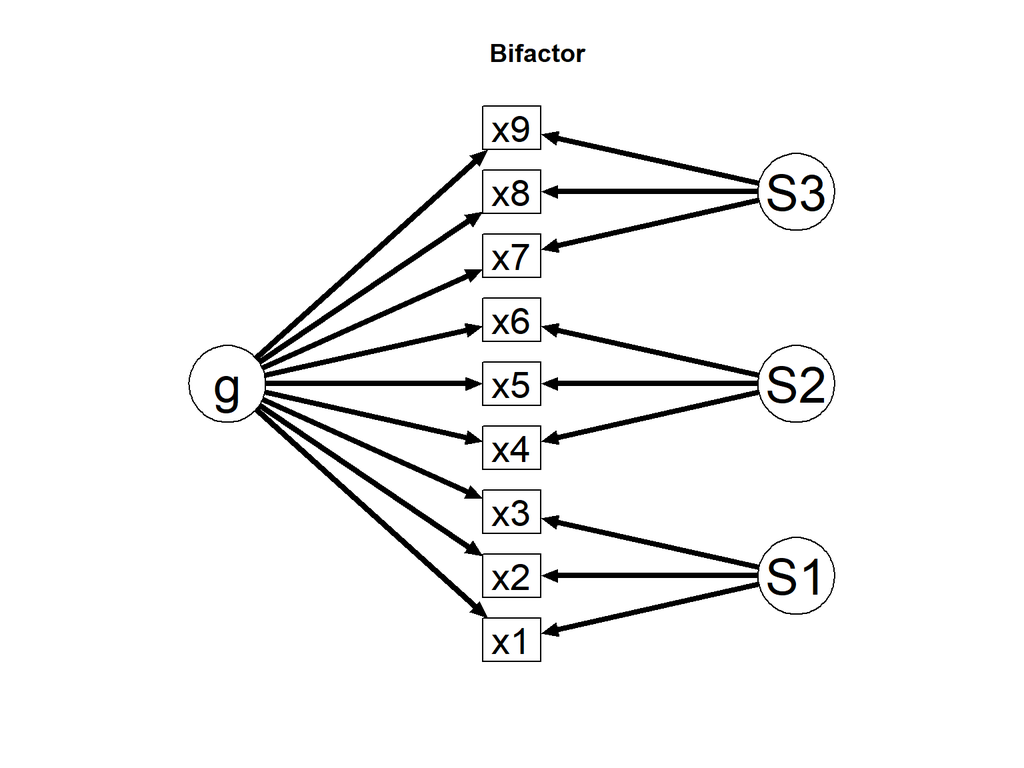

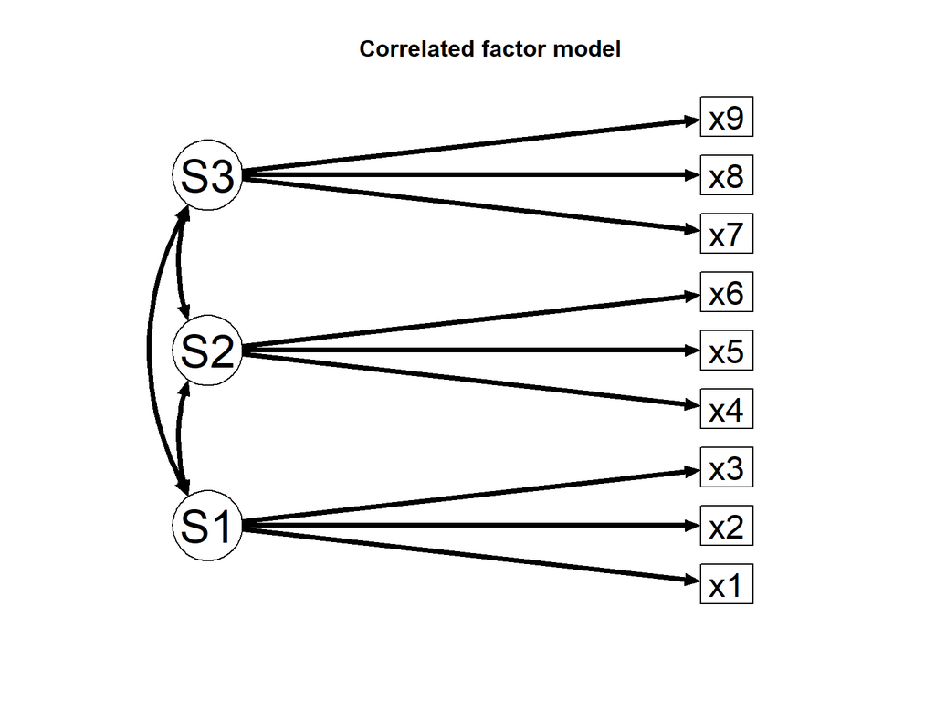

# Histórico

- As ideias iniciais de modelo bifactor retomam os trabalhos clássicos de Spearman (1904) em relação ao fator g da inteligência
- $$Desempenho = FatorG + FatorEs$$
  No caso do Spearman, havia uma tentativa de remover o erro de medida
- Outra tradição de uso da análise fatorial tem origem com os trabalhos de Thurstone, que tinha como lógica modelos de fatores correlacionados ($~$ Década de 30)
- As soluções posteriores (nesse recorte) estavam relacionadas a modelos de segunda ordem e ao uso de análise fatorial exploratória
- Outras informações podem ser vistas no capítulo 18 do livro Hoyle (2023)

# Diferença entre modelos bifactor e de segunda ordem

- Possuem semelhanças e diferenças
- Avaliam um escore geral
- Diferenças sobre o efeito direto nos itens
- Diferenças na estimativa de invariância e para estimativas em modelos de SEM completos
- Modelo bifactor pode ser utilizado a partir de 2 fatores específicos
- Modelos de segunda ordem podem ser utilizados a partir de 2 fatores específicos aplicando restrições extras (como fixando cargas fatoriais), MAS para que você possa de fato avaliar os índices de ajuste do modelo, é necessário ter pelo menos 4 fatores específicos

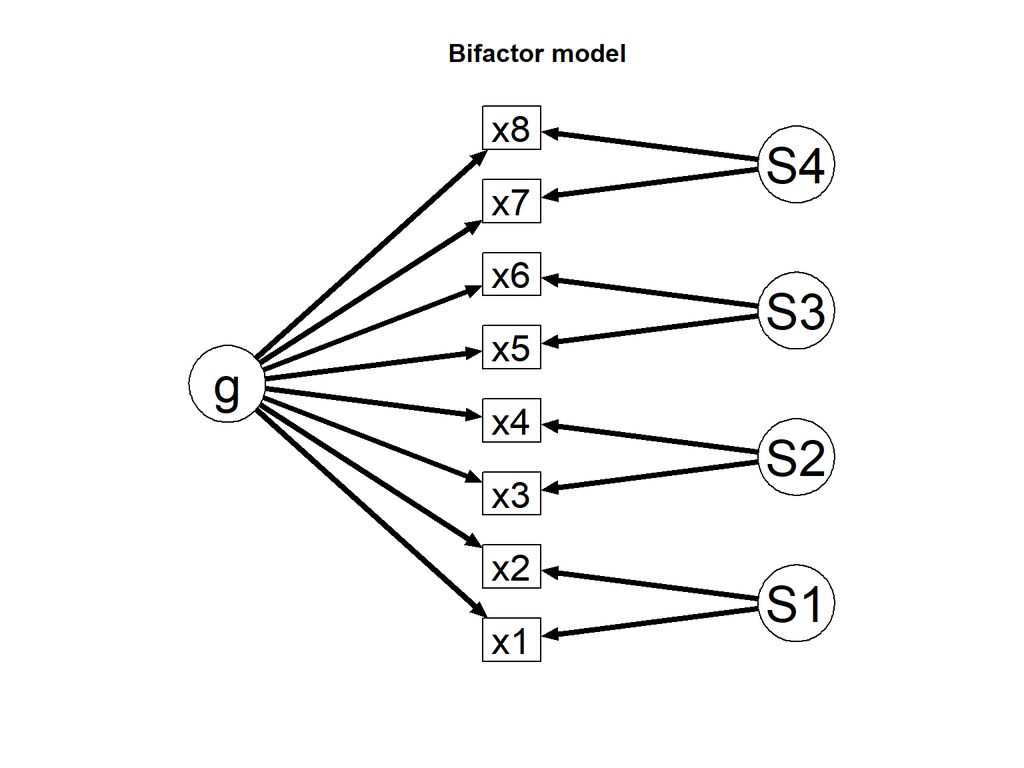

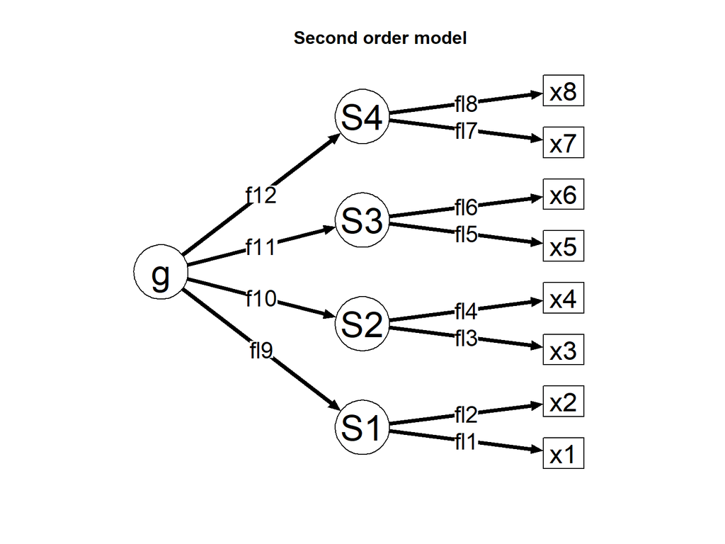

$$x1 \sim IND(fl1*fl9)$$

# Para que serve um modelo bifactor?

- Análises bi-fatoriais são representações de modelos de análise fatorial em que um fator geral compete com os fatores de domínio específico pela explicação da variância dos itens
- O fator geral, dessa forma, reflete uma dimensão que é *comum a todos os itens.* Os fatores (domínios) específicos explicam a variância que é restante, ou seja, aquilo que não é explicado pelo fator geral.
- Como pode ser visto na imagem, em modelos bi-fatoriais as variáveis latentes não são correlacionadas. Assume-se que toda a covariação existente entre os fatores específicos é explicada pelo fator geral

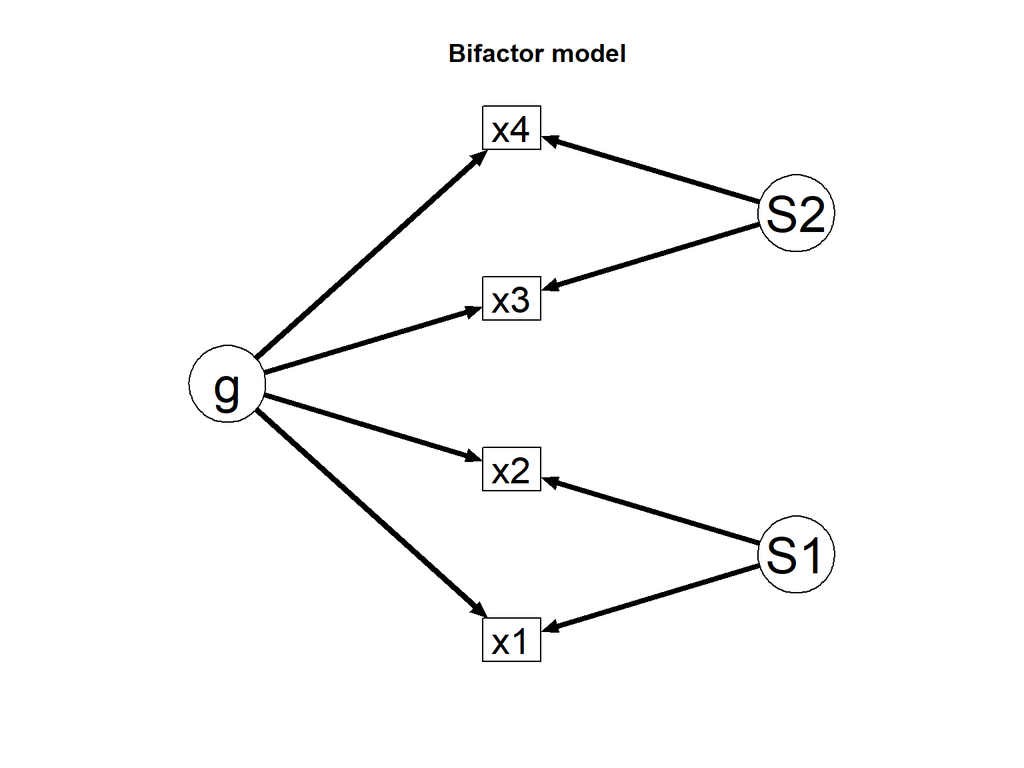

# Para que serve um modelo bifactor?

- Modelos bi-fatoriais sugerem que a estrutura de um teste é principalmente unidimensional, mas também é explicada por fatores específicos. Dessa forma, não se encontra uma solução fatorial para a escala nem utilizando um modelo com uma dimensão nem com as dimensões específicas. As duas devem coexistir.
- Modelos bi-fatoriais podem revelar fraquezas dos domínios específicos de uma escala. Por exemplo, uma dimensão que não possui cargas fatoriais relevantes após a inclusão do fator geral pode ser um indicativo de que o fator específico não é tão forte. Ou que as cargas fatoriais atribuídas ao fator não são tão relevantes ao construto.

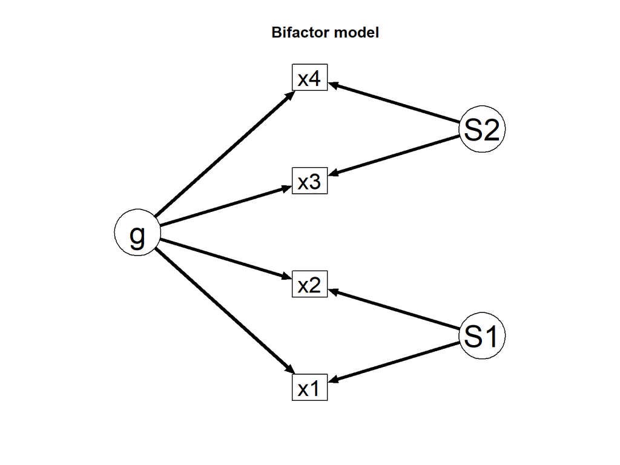

# Para que serve um modelo bifactor?

- Modelos bi-fatoriais podem ser utilizados para:
  1. repartir a variância entre o que é do fator geral e dos fatores específicos;
  2. controlar para multidimensionalidade de medidas que são unidimensionais com nuances de variância específica;
  3. julgar se os itens possuem um fator geral forte o suficiente.
  4. determinar a adequação de um escore geral para uma escala e se vale a pena utilizar escores específicos das subescalas.

# Fundamentos da análise bifactor

- A repartição da variância possível a partir de um modelo bifactor é esta:

**Fator geral** || **Fator específico** || **Variância específica** || **Erro de medida** |

- No geral, não conseguimos separar a variância específica do item, então ela é tratada como erro (conceito de nuance de McCrae 2015 talvez ajude a entender isso)

# Fundamentos da análise bifactor

- Dessa forma, a equação genérica da TCT para o desempenho $X = T + E$ precisa ser expandida (temos duas fontes de *“escore verdadeiro”*)
- Podemos estender para algo como:
- $X = C + U$
- Onde $C$ contempla o fator geral + fator específico e $U$ o erro de medida e a variância do única do item
- Isso implica que o item possui *duas* fontes de variância sistemática
- $X = T_{geral} + T_{específico} + E$
- Isso justifica a necessidade de índices específicos, portanto, para realizar uma avaliação precisa dos modelos

# Problemas com a análise

- Com a popularidade do uso, aumenta o uso selvagem
- Uma forma de refletir sobre o quão apropriado é o uso das análises bifactor está descrito no artigo

[figure not shown]

# Problemas com a análise

- Não basta usar os índices de ajuste para justificar aceitar um modelo bifactor como o modelo final
  - Uma primeira inspeção deve estar relacionada ao padrão de cargas fatoriais

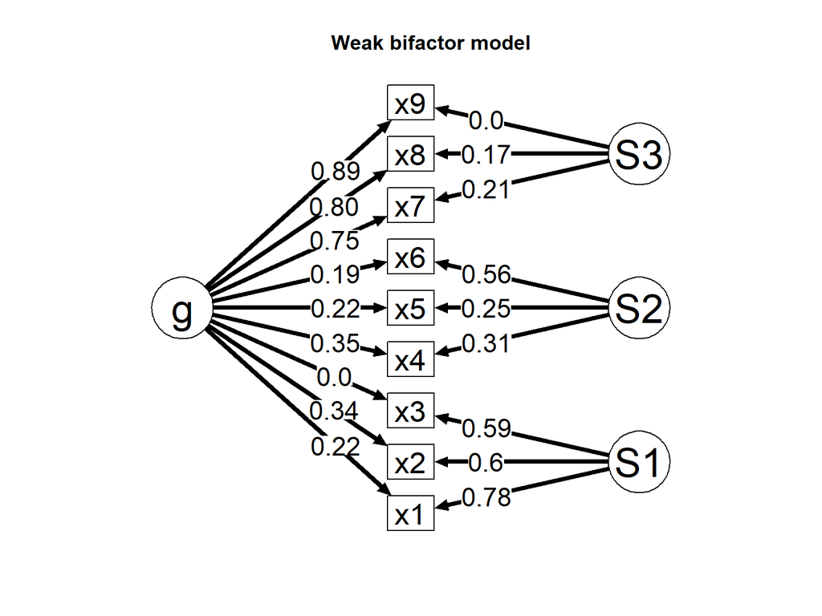

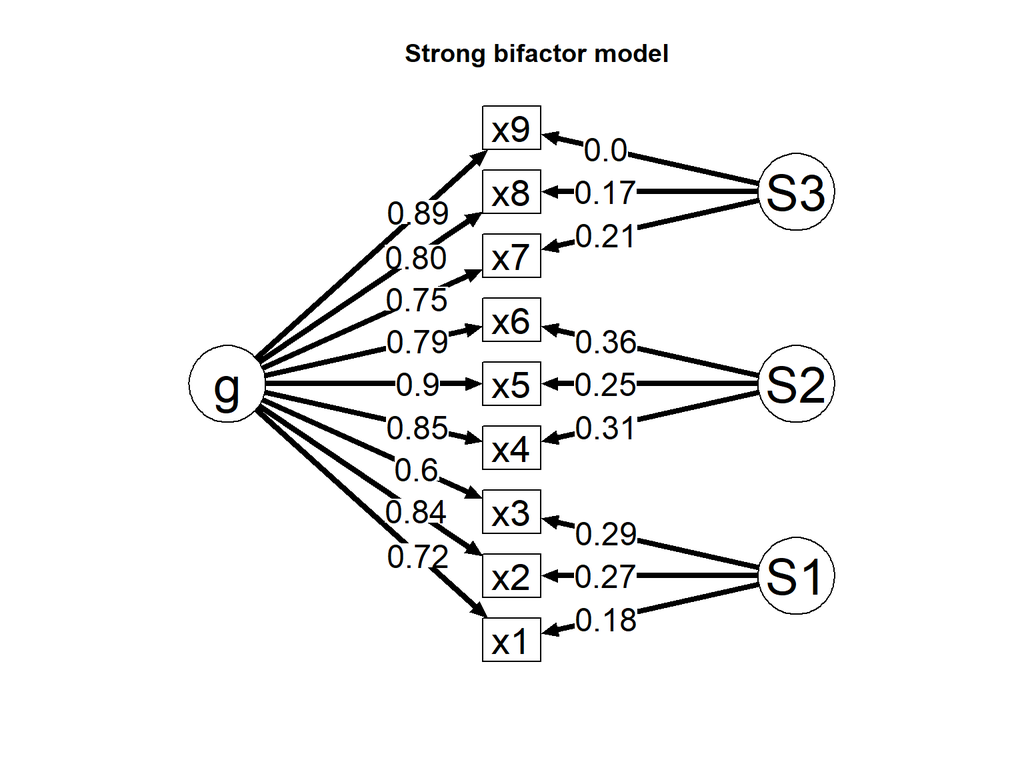

# Problemas com a análise

- É importante ter uma teoria que embase o uso do fator geral. Ele, além de forte, é passível de interpretação embasada?
- Revisando:
  - O fator geral é forte?
  - Quais fatores são confiáveis?
  - Qual é o padrão de associação dos fatores com outras variáveis?

# Índices específicos para bifactor

## Ômega hierárquico

- Considerando a desvantagem da não separação da variância do ômega tradicional, a fórmula do ômega foi expandida para criar um coeficiente de ômega hierárquico $\omega_{H}$, especialmente vantajoso para contexto de modelos bi-fatoriais
- O ômega hierárquico contabiliza a variância do fator geral tratando a variância dos fatores específicos como erro
- O coeficiente pode ser calculado facilmente utilizando a seguinte fórmula (Rodriguez et al., 2016 **equação 6**):
- $$\omega_{H} = {\frac{(\sum
  \lambda_{fator geral})²} {(\sum \lambda_{fator geral})² + (\sum
  \lambda_{fator específico1})² + (\sum \lambda_{fator específico2})² +
  \sum (1 - h²)}}$$

# Índices específicos para bifactor

## Ômega hierárquico

- A variação do ômega hierárquico é o ômega hierárquico subescala. Serve para calcular a confiabilidade dos fatores específicos
- Neste caso, a variância do fator geral é tratada como erro (Rodriguez et al., 2016 **equação 7**)
- $$\omega_{HS} = {\frac{(\sum
  \lambda_{fator específico1})²} {(\sum \lambda_{fator geral})² + (\sum
  \lambda_{fator específico1})² + \sum (1 - h²)}}$$

# Índices específicos para bifactor

## Construct reliability (replicability)

- A confiabilidade do construto ou replicabilidade do construto pode ser confundida com a consistência interna (porque recebe o mesmo nome de confiabilidade
- Uma forma de evitar essa confusão é pensar na replicabilidade do construto. O índice $H$ é uma forma de se avaliar se a variável latente é bem representada pelo conjunto de itens utilizado (ou seja, a qualidade dos indicadores. Desta forma, uma variável bem representada tende a ser mais replicável entre os estudos. Valores de pelo menos .70 devem ser alcançados
- O índice $H$ pode ser calculado usando a seguinte fórmula (Rodriguez et al., 2016 **equação 9**):
- $$H = 1/[1 + {\frac{1} {\sum_{i=1}^{k}
  {\frac{\lambda²_{i}} {1 - \lambda²_{i}}} }}]$$

Onde k é o número de itens

# Índices específicos para bifactor

## Explained common variance (ECV)

- $ECV$ serve para julgar se os itens (ou conjunto de itens) são essencialmente unidimensionais
- O $ECV$ pode ser calculado com a seguinte fórmula (Rodriguez et al., 2016 **equação 10**):

$$ECV = {\frac{(\sum \lambda_{fator
geral}^2)} {(\sum \lambda_{fator geral}^2) + (\sum \lambda_{fator
específico1}^2)+ (\sum \lambda_{fator específico2}^2)}}$$

- Um $ECV$ de 0.80 indica que o fator geral explica 80% da variância comum aos itens, enquanto os fatores específicos explicam apenas 20% (dividido entre os fatores)
- O $ECV$ também pode ser calculado para os itens individuais, tentando identificar a porcentagem de variância explicada pelo fator geral ao nível dos itens. O $ECV$ pode ser utilizado para criar uma escala mais unidimensional.
- usando $ECV-I$ para selecionar itens mais “unidimensionais” pode ser um boa ideia. para isso, sugere-se utilizar o ponto de corte de .80 ou .85

# Índices específicos para bifactor

- Basicamente, é um indicador do quanto as correlações entre as variáveis observáveis são influenciadas por um único fator dividido pela quantidade de correlações possíveis
- Indica, entre outras coisas, o quanto de informação você perde ao forçar uma solução unidimensional a um conjunto de dados multidimensional
- Quanto maior o valor de PUC, mais indicativo se tem de que a maioria das correlações são informativas do fator geral

# Aplicações usando CFA

```r
pacman::p_load(lavaan, semPlot, tidyverse)
base <- readRDS("bancobif.rds")
glimpse(base)
```

```
## Rows: 250
## Columns: 8
## $ q1 <dbl> 2, 4, 3, 3, 3, 2, 2, 2, 4, 3, 4, 3, 3, 2, 4, 2, 4, 3, 2, 3, 4, 3, 3…
## $ q2 <dbl> 2, 4, 3, 4, 3, 4, 3, 2, 3, 4, 5, 3, 4, 2, 4, 3, 3, 3, 3, 2, 4, 2, 4…
## $ q3 <dbl> 2, 3, 3, 2, 3, 2, 2, 1, 2, 2, 3, 3, 2, 2, 2, 2, 3, 2, 2, 2, 3, 2, 3…
## $ q4 <dbl> 2, 2, 3, 2, 2, 2, 2, 2, 2, 3, 3, 3, 2, 1, 2, 2, 3, 2, 2, 2, 3, 2, 3…
## $ q5 <dbl> 1, 3, 3, 4, 1, 4, 3, 2, 4, 4, 4, 4, 3, 1, 2, 5, 3, 3, 1, 4, 4, 3, 3…
## $ q6 <dbl> 2, 3, 3, 4, 1, 2, 2, 1, 2, 4, 4, 4, 3, 3, 2, 4, 4, 2, 2, 3, 4, 3, 3…
## $ q7 <dbl> 3, 3, 4, 3, 1, 2, 2, 1, 1, 3, 3, 4, 3, 2, 1, 3, 3, 2, 2, 3, 2, 1, 2…
## $ q8 <dbl> 3, 2, 2, 2, 1, 2, 2, 1, 1, 3, 3, 4, 4, 3, 2, 3, 3, 2, 2, 2, 2, 2, 2…
```

# Aplicações usando CFA

Construindo o modelo em três etapas  
1. Modelo unidimensional  
2. Modelo de fatores correlacionados  
3. Modelo bifactor

```r
model1 <- '
fator1 =~ q1 + q2 + q3 + q4 + q5 + q6 + q7 + q8
'
fit1 <- cfa(model = model1,
            data = base,
            ordered = names(base),
            estimator = "wlsmv")

summary(fit1, fit.measures = T, standardized = T)
```

```
## lavaan 0.6.15 ended normally after 26 iterations
##
##   Estimator                                       DWLS
##   Optimization method                           NLMINB
##   Number of model parameters                        39
##
##   Number of observations                           250
##
## Model Test User Model:
##                                               Standard      Scaled
##   Test Statistic                               139.956     190.615
##   Degrees of freedom                                20          20
##   P-value (Chi-square)                           0.000       0.000
##   Scaling correction factor                                  0.752
##   Shift parameter                                            4.427
##     simple second-order correction
##
## Model Test Baseline Model:
##
##   Test statistic                              3649.004    2317.049
##   Degrees of freedom                                28          28
##   P-value                                        0.000       0.000
##   Scaling correction factor                                  1.582
##
## User Model versus Baseline Model:
##
##   Comparative Fit Index (CFI)                    0.967       0.925
##   Tucker-Lewis Index (TLI)                       0.954       0.896
##
##   Robust Comparative Fit Index (CFI)                         0.788
##   Robust Tucker-Lewis Index (TLI)                            0.704
##
## Root Mean Square Error of Approximation:
##
##   RMSEA                                          0.155       0.185
##   90 Percent confidence interval - lower         0.132       0.162
##   90 Percent confidence interval - upper         0.180       0.210
##   P-value H_0: RMSEA <= 0.050                    0.000       0.000
##   P-value H_0: RMSEA >= 0.080                    1.000       1.000
##
```

[output cut: 81 more lines]

```
##    .q6                0.070                               0.070    0.070
##    .q7                0.280                               0.280    0.280
##    .q8                0.360                               0.360    0.360
##     fator1            0.320    0.056    5.718    0.000    1.000    1.000
##
## Scales y*:
##                    Estimate  Std.Err  z-value  P(>|z|)   Std.lv  Std.all
##     q1                1.000                               1.000    1.000
##     q2                1.000                               1.000    1.000
##     q3                1.000                               1.000    1.000
##     q4                1.000                               1.000    1.000
##     q5                1.000                               1.000    1.000
##     q6                1.000                               1.000    1.000
##     q7                1.000                               1.000    1.000
##     q8                1.000                               1.000    1.000
```

# Aplicações usando CFA

```r
model2 <- '
fator1 =~ q1 + q2 + q3 + q4
fator2 =~  q5 + q6 + q7 + q8
'
fit2 <- cfa(model = model2,
            data = base,
            ordered = names(base),
            estimator = "wlsmv")

summary(fit2, fit.measures = T, standardized = T)
```

```
## lavaan 0.6.15 ended normally after 22 iterations
##
##   Estimator                                       DWLS
##   Optimization method                           NLMINB
##   Number of model parameters                        40
##
##   Number of observations                           250
##
## Model Test User Model:
##                                               Standard      Scaled
##   Test Statistic                                 8.153      15.566
##   Degrees of freedom                                19          19
##   P-value (Chi-square)                           0.985       0.686
##   Scaling correction factor                                  0.665
##   Shift parameter                                            3.304
##     simple second-order correction
##
## Model Test Baseline Model:
##
##   Test statistic                              3649.004    2317.049
##   Degrees of freedom                                28          28
##   P-value                                        0.000       0.000
##   Scaling correction factor                                  1.582
##
## User Model versus Baseline Model:
##
##   Comparative Fit Index (CFI)                    1.000       1.000
##   Tucker-Lewis Index (TLI)                       1.004       1.002
##
##   Robust Comparative Fit Index (CFI)                         1.000
##   Robust Tucker-Lewis Index (TLI)                            1.004
##
## Root Mean Square Error of Approximation:
##
##   RMSEA                                          0.000       0.000
##   90 Percent confidence interval - lower         0.000       0.000
##   90 Percent confidence interval - upper         0.000       0.044
##   P-value H_0: RMSEA <= 0.050                    1.000       0.972
##   P-value H_0: RMSEA >= 0.080                    0.000       0.000
##
```

[output cut: 89 more lines]

```
##    .q7                0.255                               0.255    0.255
##    .q8                0.320                               0.320    0.320
##     fator1            0.467    0.069    6.781    0.000    1.000    1.000
##     fator2            0.347    0.055    6.350    0.000    1.000    1.000
##
## Scales y*:
##                    Estimate  Std.Err  z-value  P(>|z|)   Std.lv  Std.all
##     q1                1.000                               1.000    1.000
##     q2                1.000                               1.000    1.000
##     q3                1.000                               1.000    1.000
##     q4                1.000                               1.000    1.000
##     q5                1.000                               1.000    1.000
##     q6                1.000                               1.000    1.000
##     q7                1.000                               1.000    1.000
##     q8                1.000                               1.000    1.000
```

# Aplicações usando CFA

```r
model3 <- '
fator1 =~ q1 + q2 + q3 + q4
fator2 =~  q5 + q6 + q7 + q8
geral =~ q1 + q2 + q3 + q4 + q5 + q6 + q7 + q8
'
fit3 <- cfa(model = model3,
            data = base,
            ordered = names(base),
            estimator = "wlsmv",
            std.lv = T)
```

# Aplicações usando CFA

```r
model3 <- '
fator1 =~ q1 + q2 + q3 + q4
fator2 =~  q5 + q6 + q7 + q8
geral =~ q1 + q2 + q3 + q4 + q5 + q6 + q7 + q8
'
fit3 <- cfa(model = model3,
            data = base,
            ordered = names(base),
            estimator = "wlsmv",
            std.lv = T,
            orthogonal = T)

summary(fit3, fit.measures = T, standardized = T)
```

```
## lavaan 0.6.15 ended normally after 35 iterations
##
##   Estimator                                       DWLS
##   Optimization method                           NLMINB
##   Number of model parameters                        47
##
##   Number of observations                           250
##
## Model Test User Model:
##                                               Standard      Scaled
##   Test Statistic                                 4.155      11.332
##   Degrees of freedom                                12          12
##   P-value (Chi-square)                           0.980       0.501
##   Scaling correction factor                                  0.401
##   Shift parameter                                            0.959
##     simple second-order correction
##
## Model Test Baseline Model:
##
##   Test statistic                              3649.004    2317.049
##   Degrees of freedom                                28          28
##   P-value                                        0.000       0.000
##   Scaling correction factor                                  1.582
##
## User Model versus Baseline Model:
##
##   Comparative Fit Index (CFI)                    1.000       1.000
##   Tucker-Lewis Index (TLI)                       1.005       1.001
##
##   Robust Comparative Fit Index (CFI)                         1.000
##   Robust Tucker-Lewis Index (TLI)                            1.002
##
## Root Mean Square Error of Approximation:
##
##   RMSEA                                          0.000       0.000
##   90 Percent confidence interval - lower         0.000       0.000
##   90 Percent confidence interval - upper         0.000       0.062
##   P-value H_0: RMSEA <= 0.050                    0.999       0.879
##   P-value H_0: RMSEA >= 0.080                    0.000       0.007
##
```

[output cut: 103 more lines]

```
##    .q8                0.285                               0.285    0.285
##     fator1            1.000                               1.000    1.000
##     fator2            1.000                               1.000    1.000
##     geral             1.000                               1.000    1.000
##
## Scales y*:
##                    Estimate  Std.Err  z-value  P(>|z|)   Std.lv  Std.all
##     q1                1.000                               1.000    1.000
##     q2                1.000                               1.000    1.000
##     q3                1.000                               1.000    1.000
##     q4                1.000                               1.000    1.000
##     q5                1.000                               1.000    1.000
##     q6                1.000                               1.000    1.000
##     q7                1.000                               1.000    1.000
##     q8                1.000                               1.000    1.000
```

# Gráfico

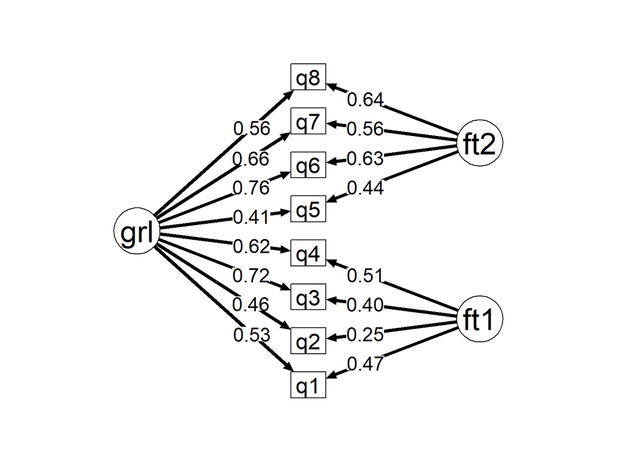

```r
semPaths(fit3,
         whatLabels = "std.all",edge.label.cex = 1.5,
         edge.label.position = .7,
         style = "lisrel",sizeMan=6,sizeMan2=4.5,label.cex = 2,
         edge.color = "black",rotation = 2,esize=4,asize = 4,
         residuals=FALSE,layout = "tree2",bifactor = "geral",
         thresholds = F, intercepts = F,
         exoCov = FALSE)
```

# Calculando os índices

```r
library(BifactorIndicesCalculator)
bifactorIndices(fit3)
```

```
## $ModelLevelIndices
##    ECV.geral          PUC  Omega.geral OmegaH.geral
##    0.5906666    0.5714286    0.8762508    0.6416561
##
## $FactorLevelIndices
##           ECV_SS    ECV_SG    ECV_GS     Omega    OmegaH         H        FD
## fator1 0.3308446 0.1421720 0.6691554 0.7596042 0.2438182 0.4690666 0.6573912
## fator2 0.4684777 0.2671613 0.5315223 0.8513431 0.3993258 0.6710266 0.7946092
## geral  0.5906666 0.5906666 0.5906666 0.8762508 0.6416561 0.8381952 0.8619087
##
## $ItemLevelIndices
##         IECV
## q1 0.5644127
## q2 0.7823218
## q3 0.7699221
## q4 0.5964207
## q5 0.4598416
## q6 0.5909457
## q7 0.5821197
## q8 0.4333754
```

# Referências

- Bornovalova, M. A., Choate, A. M., Fatimah, H., Petersen, K. J., & Wiernik, B. M. (2020). Appropriate use of bifactor analysis in psychopathology research: Appreciating benefits and limitations. Biological Psychiatry, 88(1), 18-27.
- Hoyle, R. H. (Ed.). (2023). Handbook of structural equation modeling. Guilford press.
- Rodriguez, A., Reise, S. P., & Haviland, M. G. (2016). Evaluating bifactor models: Calculating and interpreting statistical indices. Psychological methods, 21(2), 137.

# Adendo - aplicações com EFA

```r
library(psych)
library(GPArotation)
```

# Transformação Schmid-Leiman

Necessita que sejam pelo menos 3 fatores específicos :(

```r
corrs <- polychoric(base)$rho
fitsch <- schmid(corrs, nfactors = 2, fm = "minres", rotate = "oblimin")
```

```
##
## Three factors are required for identification -- general factor loadings set to be equal.
## Proceed with caution.
## Think about redoing the analysis with alternative values of the 'option' setting.
```

```r
fitsch <- schmid(corrs, nfactors = 3, fm = "minres", rotate = "oblimin")
fitsch
```

```
## Schmid-Leiman analysis
## Call: schmid(model = corrs, nfactors = 3, fm = "minres", rotate = "oblimin")
##
## Schmid Leiman Factor loadings greater than  0.2
##       g   F1*   F2*   F3*   h2   u2   p2
## q1 0.72                   0.56 0.44 0.93
## q2 0.53                   0.30 0.70 0.92
## q3 0.74                   0.61 0.39 0.91
## q4 0.75              0.66 1.00 0.00 0.56
## q5 0.33  0.50             0.35 0.65 0.31
## q6 0.59  0.79             0.98 0.02 0.36
## q7 0.50  0.71             0.76 0.24 0.33
## q8 0.47  0.70             0.73 0.27 0.30
##
## With eigenvalues of:
##    g  F1*  F2*  F3*
## 2.84 1.88 0.08 0.49
##
## general/max  1.51   max/min =   23.85
## mean percent general =  0.58    with sd =  0.3 and cv of  0.51
##
##  The orthogonal loadings were
## Unstandardized loadings based upon covariance matrix
##      F1   F2   F3   h2   u2   H2   U2
## q1 0.18 0.70 0.19 0.56 0.44 0.56 0.44
## q2 0.20 0.51 0.09 0.30 0.70 0.30 0.70
## q3 0.32 0.64 0.31 0.61 0.39 0.61 0.39
## q4 0.18 0.54 0.82 1.00 0.00 1.00 0.00
## q5 0.57 0.15 0.07 0.35 0.65 0.35 0.65
## q6 0.93 0.30 0.18 0.98 0.02 0.98 0.02
## q7 0.81 0.22 0.22 0.76 0.24 0.76 0.24
## q8 0.82 0.24 0.00 0.73 0.27 0.73 0.27
##
##                  F1   F2   F3
## SS loadings    2.72 1.67 0.89
## Proportion Var 0.34 0.21 0.11
## Cumulative Var 0.34 0.55 0.66
##
## The degrees of freedom are 7  and the fit is  0.06
##
## The root mean square of the residuals is  0.01
## The df corrected root mean square of the residuals is  0.03
```

# Método Jenrich e Bentler

```r
fitjb <- fa(base, nfactors = 3, rotate = "bifactor", cor = "poly")
fitjb
```

```
## Factor Analysis using method =  minres
## Call: fa(r = base, nfactors = 3, rotate = "bifactor", cor = "poly")
## Standardized loadings (pattern matrix) based upon correlation matrix
##     MR1   MR2   MR3   h2     u2 com
## q1 0.57 -0.04  0.48 0.56 0.4449 2.0
## q2 0.42  0.05  0.35 0.30 0.6950 2.0
## q3 0.70  0.01  0.34 0.61 0.3916 1.5
## q4 0.93 -0.37  0.04 1.00 0.0046 1.3
## q5 0.43  0.41 -0.01 0.35 0.6465 2.0
## q6 0.77  0.62 -0.01 0.98 0.0175 1.9
## q7 0.70  0.52 -0.07 0.76 0.2394 1.9
## q8 0.56  0.64  0.05 0.73 0.2732 2.0
##
##                        MR1  MR2  MR3
## SS loadings           3.42 1.38 0.48
## Proportion Var        0.43 0.17 0.06
## Cumulative Var        0.43 0.60 0.66
## Proportion Explained  0.65 0.26 0.09
## Cumulative Proportion 0.65 0.91 1.00
##
## Mean item complexity =  1.8
## Test of the hypothesis that 3 factors are sufficient.
##
## The degrees of freedom for the null model are  28  and the objective function was  4.75 with Chi Square of  1165.62
## The degrees of freedom for the model are 7  and the objective function was  0.06
##
## The root mean square of the residuals (RMSR) is  0.01
## The df corrected root mean square of the residuals is  0.03
##
## The harmonic number of observations is  250 with the empirical chi square  3.04  with prob <  0.88
## The total number of observations was  250  with Likelihood Chi Square =  13.82  with prob <  0.054
##
## Tucker Lewis Index of factoring reliability =  0.976
## RMSEA index =  0.062  and the 90 % confidence intervals are  0 0.111
## BIC =  -24.83
## Fit based upon off diagonal values = 1
## Measures of factor score adequacy
##                                                    MR1  MR2   MR3
## Correlation of (regression) scores with factors   1.00 0.99  0.70
## Multiple R square of scores with factors          1.00 0.97  0.49
## Minimum correlation of possible factor scores     0.99 0.95 -0.01
```

# Método Jenrich e Bentler

```r
fitjb2 <- fa(base, nfactors = 3, rotate = "biquartimin", cor = "poly")
fitjb2
```

```
## Factor Analysis using method =  minres
## Call: fa(r = base, nfactors = 3, rotate = "biquartimin", cor = "poly")
## Standardized loadings (pattern matrix) based upon correlation matrix
##     MR1   MR2   MR3   h2     u2 com
## q1 0.54 -0.01  0.51 0.56 0.4449 2.0
## q2 0.43  0.07  0.38 0.30 0.6950 2.0
## q3 0.67 -0.07  0.35 0.61 0.3916 1.5
## q4 0.75 -0.66  0.01 1.00 0.0046 2.0
## q5 0.54  0.23 -0.03 0.35 0.6465 1.4
## q6 0.93  0.31 -0.04 0.98 0.0175 1.2
## q7 0.83  0.21 -0.11 0.76 0.2394 1.2
## q8 0.74  0.44  0.04 0.73 0.2732 1.6
##
##                        MR1  MR2  MR3
## SS loadings           3.89 0.84 0.56
## Proportion Var        0.49 0.11 0.07
## Cumulative Var        0.49 0.59 0.66
## Proportion Explained  0.74 0.16 0.11
## Cumulative Proportion 0.74 0.89 1.00
##
##  With factor correlations of
##     MR1   MR2   MR3
## MR1   1  0.00  0.00
## MR2   0  1.00 -0.45
## MR3   0 -0.45  1.00
##
## Mean item complexity =  1.6
## Test of the hypothesis that 3 factors are sufficient.
##
## The degrees of freedom for the null model are  28  and the objective function was  4.75 with Chi Square of  1165.62
## The degrees of freedom for the model are 7  and the objective function was  0.06
##
## The root mean square of the residuals (RMSR) is  0.01
## The df corrected root mean square of the residuals is  0.03
##
## The harmonic number of observations is  250 with the empirical chi square  3.04  with prob <  0.88
## The total number of observations was  250  with Likelihood Chi Square =  13.82  with prob <  0.054
##
## Tucker Lewis Index of factoring reliability =  0.976
## RMSEA index =  0.062  and the 90 % confidence intervals are  0 0.111
## BIC =  -24.83
## Fit based upon off diagonal values = 1
## Measures of factor score adequacy
##                                                    MR1  MR2  MR3
## Correlation of (regression) scores with factors   1.00 0.99 0.78
## Multiple R square of scores with factors          0.99 0.98 0.61
## Minimum correlation of possible factor scores     0.99 0.96 0.22
```

# Rotação Target

```r
targ <- make.keys(8, list(geral = 1:8, f1 = c(1:4), f2 = c(5:8)))
targ <- scrub(targ, isvalue=1)
targ <- list(targ)
targ
```

```
## [[1]]
##      geral f1 f2
## [1,]    NA NA  0
## [2,]    NA NA  0
## [3,]    NA NA  0
## [4,]    NA NA  0
## [5,]    NA  0 NA
## [6,]    NA  0 NA
## [7,]    NA  0 NA
## [8,]    NA  0 NA
```

# Rotação target

```r
fittarget <- fa(base, nfactors = 3, rotate = "TargetQ",
                Target = targ,
                cor = "poly")
fittarget
```

```
## Factor Analysis using method =  minres
## Call: fa(r = base, nfactors = 3, rotate = "TargetQ", cor = "poly",
##     Target = targ)
## Standardized loadings (pattern matrix) based upon correlation matrix
##      MR3   MR2   MR1   h2     u2 com
## q1 -0.09  0.87 -0.23 0.56 0.4449 1.2
## q2  0.02  0.60 -0.20 0.30 0.6950 1.2
## q3  0.10  0.74 -0.06 0.61 0.3916 1.0
## q4 -0.02  0.70  0.48 1.00 0.0046 1.8
## q5  0.60 -0.02  0.05 0.35 0.6465 1.0
## q6  0.96  0.04  0.11 0.98 0.0175 1.0
## q7  0.86 -0.02  0.19 0.76 0.2394 1.1
## q8  0.85  0.00 -0.05 0.73 0.2732 1.0
##
##                        MR3  MR2  MR1
## SS loadings           2.78 2.14 0.37
## Proportion Var        0.35 0.27 0.05
## Cumulative Var        0.35 0.61 0.66
## Proportion Explained  0.53 0.41 0.07
## Cumulative Proportion 0.53 0.93 1.00
##
##  With factor correlations of
##      MR3  MR2  MR1
## MR3 1.00 0.54 0.03
## MR2 0.54 1.00 0.44
## MR1 0.03 0.44 1.00
##
## Mean item complexity =  1.2
## Test of the hypothesis that 3 factors are sufficient.
##
## The degrees of freedom for the null model are  28  and the objective function was  4.75 with Chi Square of  1165.62
## The degrees of freedom for the model are 7  and the objective function was  0.06
##
## The root mean square of the residuals (RMSR) is  0.01
## The df corrected root mean square of the residuals is  0.03
##
## The harmonic number of observations is  250 with the empirical chi square  3.04  with prob <  0.88
## The total number of observations was  250  with Likelihood Chi Square =  13.82  with prob <  0.054
##
## Tucker Lewis Index of factoring reliability =  0.976
## RMSEA index =  0.062  and the 90 % confidence intervals are  0 0.111
## BIC =  -24.83
## Fit based upon off diagonal values = 1
## Measures of factor score adequacy
##                                                    MR3  MR2  MR1
## Correlation of (regression) scores with factors   0.99 0.96 0.91
## Multiple R square of scores with factors          0.98 0.92 0.83
## Minimum correlation of possible factor scores     0.97 0.85 0.66
```